# Practical Machine Learning Project

Timothy Hochberg

Aug 10, 2015

## Goal

The goal of this project is to predict how in what manner each participant in a study is performing a dumbell lift, at a given time, based on data collected using accelerometers mounted on the belt, forearm, arm, and dumbell of each particpants. Each participant performed the lift in six different ways: one correctly and five incorrectly.

## Load the Preprocess the Training Data

We first load the raw training data, taking care to convert the non-numeric strings that appear in the data to NA.

```r
raw_train = read.csv("pml-training.csv", na.strings=c("NA", "#DIV/0!"))
dim(raw_train)
```

```
## [1] 19622   160
```

```r
head(names(raw_train), 10)
```

```
##  [1] "X"                    "user_name"            "raw_timestamp_part_1"
##  [4] "raw_timestamp_part_2" "cvtd_timestamp"       "new_window"
##  [7] "num_window"           "roll_belt"            "pitch_belt"
## [10] "yaw_belt"
```

```r
tail(names(raw_train), 10)
```

```
##  [1] "gyros_forearm_x"  "gyros_forearm_y"  "gyros_forearm_z"
##  [4] "accel_forearm_x"  "accel_forearm_y"  "accel_forearm_z"
##  [7] "magnet_forearm_x" "magnet_forearm_y" "magnet_forearm_z"
## [10] "classe"
```

The specification of the different ways of performing the lift are contained in the last column, labelled `classe`, and are represented by the letters `A` - `E`. The first seven columns contain timestamps and other non-sensor data and the remaining columns contain accelerometer data that can be used in the predictions

We first remove the non sensor data and then examine the resulting data to see which columns have missing or NA values.

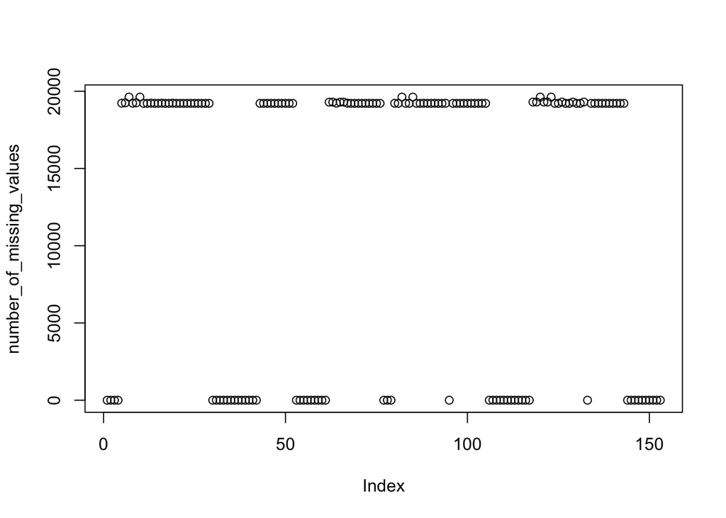

```r
library(caret)
library(randomForest)
# Remove the non-sensor data in rows 1-7
pruned_raw_train <- raw_train[,-(1:7)]
number_of_missing_values <- colSums(is.na(pruned_raw_train))
plot(number_of_missing_values)
```

Examination of `number_of_missing_values` reveals that that the columns can be separated into sets: one  
that is missing no data, and another which is missing all, or nearly all values. So, rather than trying to impute any values, we simply remove the offending columns.

```r
has_all_data <- number_of_missing_values == 0
train_with_no_missing = pruned_raw_train[,has_all_data]
```

We then break the data into training and validation set so that we can get evaluate the out of sample (OOS) error.

```r
set.seed(3456)
train_index <- createDataPartition(train_with_no_missing$classe, p = .6, list=FALSE)

train = train_with_no_missing[train_index,]
valid = train_with_no_missing[-train_index,]
```

## Create a Random Forest model.

We create a random forest model to predict `classe`. The data is preprocessed by scaling and centering the predictors and we perform 5-fold cross validation in order to get an *estimate* of the error.

```r
model<-train(classe ~ ., data=train, method="rf",
              preProcess=c('scale','center'),
              trControl=trainControl(method="cv", number=5))
model$results[1,]
```

```
##   mtry  Accuracy     Kappa  AccuracySD     KappaSD
## 1    2 0.9904041 0.9878614 0.001766953 0.002235252
```

The model is then applied to the validation data to provide an estimate of the out of sample error.

```r
predict = predict(model, valid)
confmatrix <-confusionMatrix(predict, valid$classe)
confmatrix$table
```

```
##           Reference
## Prediction    A    B    C    D    E
##          A 2232    9    0    0    0
##          B    0 1506   18    0    0
##          C    0    3 1349   23    2
##          D    0    0    1 1262    3
##          E    0    0    0    1 1437
```

```r
confmatrix$overall
```

```
##       Accuracy          Kappa  AccuracyLower  AccuracyUpper   AccuracyNull
##      0.9923528      0.9903253      0.9901673      0.9941594      0.2844762
## AccuracyPValue  McnemarPValue
##      0.0000000            NaN
```

The estimate of the model accuracy provided by cross-validation on the test set is 99.0%. The agrees closely with the 99.2% OOS accuracy measured on the validation set. Interestingly, the OOS accuracy is slightly higher than the cross validation accuracy, a reversal of the typical pattern.

## Summary

We generated a random forest model that predicts, based on the valid accelerometer data for the participants, the way in which they were lifing dumbells during a given trial. The out of sample accuracy was determined to be 99.2% based on a validation set consisting of 40% of the available data.

# Appendix

## Write Data for Assigments

```r
pml_write_files = function(x){
  n = length(x)
  for(i in 1:n){
    filename = paste0("problem_id_",i,".txt")
    write.table(x[i],file=filename,quote=FALSE,row.names=FALSE,col.names=FALSE)
  }
}

# Generate and write the output files.

raw_test = read.csv("pml-testing.csv", na.strings=c("NA", "#DIV/0!"))
test = raw_test[,-(1:7)][,has_all_data] # Remove non sensor data
answers = predict(model, test)

pml_write_files(answers)
```